# LStages-micro

A Model with n-Larval Stages for exDE

David Smith

2022-10-28

$\uparrow$ Library || Aquatic Ecology

For **BIMEP**

- We need to evaluate the optimal interval for treating habitats with either
  - Larvicides (*e.g.*, BTI)
  - Pupicides (*e.g*, Novalarone)
- We need to evaluate the size of a buffer area around aquatic habitats to treat
- We need to evaluate the effectiveness of these strategies in combination with
  - IRS
  - Auto-disseminated Larvicides.

To do this project, we will need to use `MicroMoB.` The current module is the [Beverton Holt Model](https://cran.r-project.org/web/packages/MicroMoB/vignettes/BH_aqua.html).

## `stage4L`

We use this general notation:

- $\mu_i$ is fraction surviving
- $\theta_i$ is fraction maturing

$$\begin{array}{rl}
L_{1,t+1} &= \eta_t + \mu_1 (1-\theta_1) L_{1,t} \\
L_{2,t+1} & = \mu_1 \theta_1 L_{1,t} + \mu_2(1-\theta_2) L_{2,t} \\
L_{3,t+1} & = \mu_2 \theta_2 L_{2,t} + \mu_3(1-\theta_3) L_{3,t} \\
L_{4,t+1} & = \mu_3 \theta_3 L_{3,t} + \mu_4(1-\theta_4) L_{4,t} \\
P_{t+1} & = \mu_4 \theta_4 L_{4,t} + \mu_P(1-\theta_P) P_t \\
\Lambda_t &= \mu_P \theta_P P_t
\end{array}$$
The minimum time to go from egg to adult is 5 days.

## `stage6L`

- In this model, $L_1$ and $L_2$ are first instars:
- In this model, $L_3$ and $L_4$ are second instars:

$$\begin{array}{rl}
L_{1,t+1} &= \eta_t + \mu_1 (1-\theta_1) L_{1,t} \\
L_{2,t+1} & = \mu_1 \theta_1 L_{1,t} + \mu_2(1-\theta_2) L_{2,t} \\
L_{3,t+1} & = \mu_2 \theta_2 L_{2,t} + \mu_3(1-\theta_3) L_{3,t} \\
L_{4,t+1} & = \mu_3 \theta_3 L_{3,t} + \mu_4(1-\theta_4) L_{4,t} \\
L_{5,t+1} & = \mu_4 \theta_4 L_{4,t} + \mu_5(1-\theta_5) L_{5,t} \\
L_{6,t+1} & = \mu_5 \theta_5 L_{5,t} + \mu_6(1-\theta_6) L_{6,t} \\
P_{t+1} & = \mu_6 \theta_6 L_{6,t} + \mu_P(1-\theta_P) P_t \\
\Lambda_t &= \mu_P \theta_P P_t
\end{array}$$

The minimum time to go from egg to adult is 7 days.

## `stage8L`

- In this model, $L_1$ and $L_2$ are first instars:
- In this model, $L_3$ and $L_4$ are second instars:
- In this model, $L_5$ and $L_6$ are third instars:
- In this model, $L_7$ and $L_7$ are fourth instars:

$$\begin{array}{rl}
G_{t+1} &= \nu M_t \\
L_{1,t+1} &= \eta_t + \mu_1 (1-\theta_1) L_{1,t} \\
L_{2,t+1} & = \mu_1 \theta_1 L_{1,t} + \mu_2(1-\theta_2) L_{2,t} \\
L_{3,t+1} & = \mu_2 \theta_2 L_{2,t} + \mu_3(1-\theta_3) L_{3,t} \\
L_{4,t+1} & = \mu_3 \theta_3 L_{3,t} + \mu_4(1-\theta_4) L_{4,t} \\
L_{5,t+1} & = \mu_4 \theta_4 L_{4,t} + \mu_5(1-\theta_5) L_{5,t} \\
L_{6,t+1} & = \mu_5 \theta_5 L_{5,t} + \mu_6(1-\theta_6) L_{6,t} \\
L_{7,t+1} & = \mu_6 \theta_6 L_{6,t} + \mu_7(1-\theta_7) L_{7,t} \\
L_{8,t+1} & = \mu_7 \theta_7 L_{7,t} + \mu_8(1-\theta_8) L_{8,t} \\
P_{t+1} & = \mu_8 \theta_8 L_{8,t} + \mu_P(1-\theta_P) P_t \\
\Lambda_t &= \mu_P \theta_P P_t \\
M_{t+1} &= \Lambda_{t} + p M_t
\end{array}$$
The minimum time to go from egg to adult is 9 days.

## Code

Here, we implement a generalized $N-$stage model

```r
dL = function(vars, params){with(c(vars,params),{
  totL  = sum(L)
  dose  = ifelse(t%%re_treat == 0, 1, 0)*bti_dose
  mu    = mu0*exp(-muD*totL)*exp(-bti*bti_mu)
  theta = theta0*exp(-thetaD*totL)


  bti = bti_dk*bti + dose
  L = mu*L
  Lt = (1-theta)*L
  Lt[-1] = Lt[-1] + theta[-N]*L[-N]
  Lt[1] =  Lt[1] + params$eggs*M
  Pt = theta[N]*L[N]
  Lambdat = P
  Mt = Lambda + .95*M
  vars = list(t=t+1, bti=bti, L = Lt, P = Pt, Lambda=Lambdat, M=Mt)
  return(vars)
})}
```

```r
sdL = function(vars, params){with(c(vars, params),{
  totL  = sum(L)
  dose  = ifelse(t%%re_treat == 0, 1, 0)*bti_dose
  mu    = mu0*exp(-muD*totL)*exp(-bti*bti_mu)
  theta = theta0*exp(-thetaD*totL)

  bti = bti_dk*bti + dose
  survive = rbinom(N, L, mu)
  mature = rbinom(N, survive, theta)
  Lt = survive-mature
  Lt[-1] = Lt[-1] + mature[-N]
  Pt = mature[N]
  Lt[1] =  Lt[1] + rpois(1,params$eggs*M)
  Lambdat = P
  Mt = Lambda + rbinom(1, M, .95)
  vars = list(t=t+1, bti=bti, L = Lt, P = Pt, Lambda=Lambdat, M=Mt)
  return(vars)
})}
```

```r
makePars = function(N=8){
  mu0 = .99*rep(1,8)
  theta0 = .99*rep(1,8)
  muD = .00001
  thetaD = .00001
  params = list(N=8, mu0=mu0, muD=muD, theta0=theta0, thetaD=thetaD, re_treat = 15, bti_dk = .9, bti_mu = .2, bti_dose=2, eggs=200)
  return(params)
}
params = makePars()
```

```r
L = rep(0,8)
P = 0
P = 0
vars = V0 =  list(t=0, bti=0, L=L, P=P, Lambda=0, M=10)
#dL(vars, params)
```

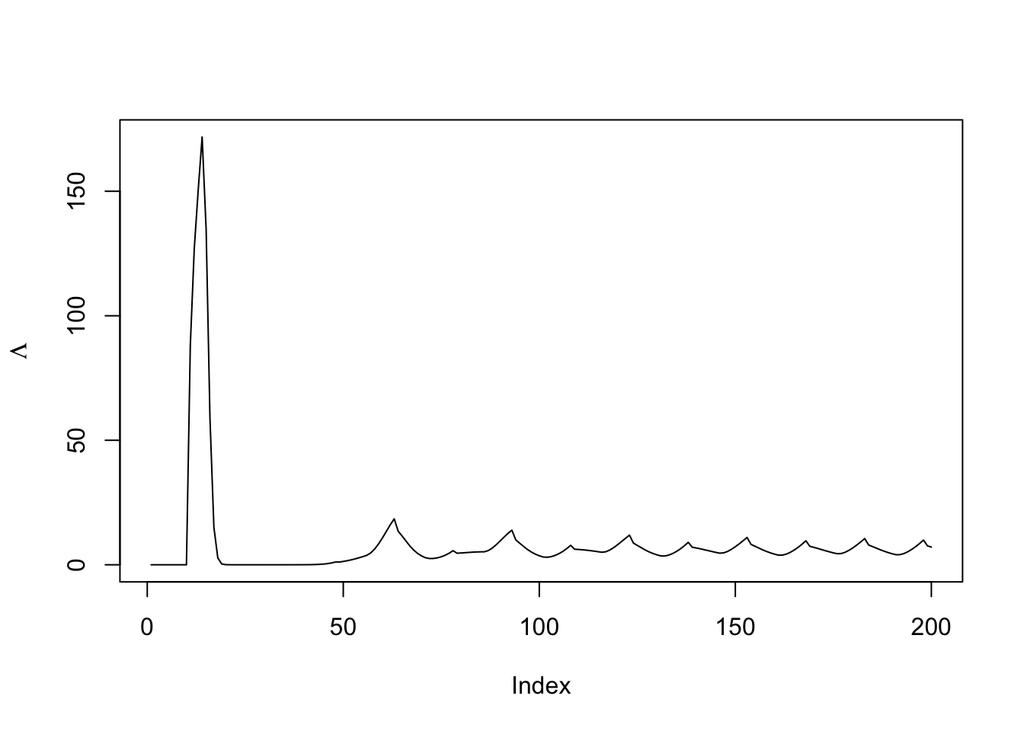

```r
dL_iterate = function(vars, params, maxT=200, after=1, mtl=NULL){
  vars = V0
  V = unlist(vars)
  for(i in 1:maxT){
    dL(vars, params) -> vars
    V = rbind(V, unlist(vars))
  }
  if(after < maxT) plot(V[after:maxT,12], type = "l", ylab = expression(Lambda), main = mtl)
  return(V)
}
dL_iterate(vars, params) -> V1
```

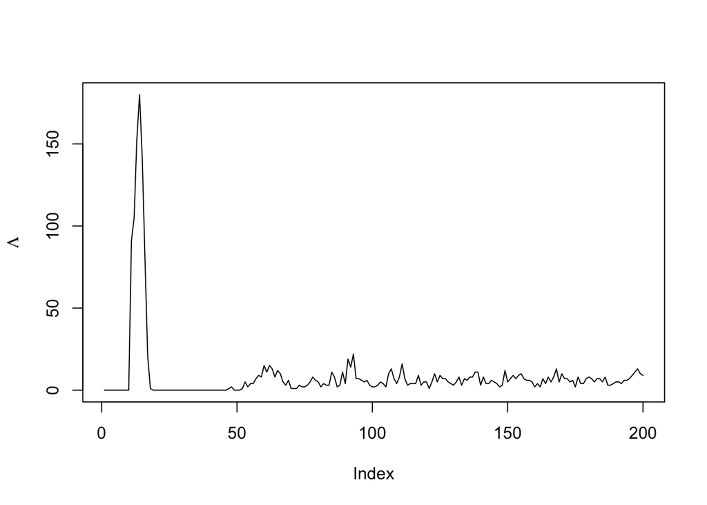

```r
sdL_iterate = function(vars, params, maxT=200, after=1, mtl=NULL){
  vars = V0
  V = unlist(vars)
  for(i in 1:maxT){
    sdL(vars, params) -> vars
    V = rbind(V, unlist(vars))
  }
  if(after < maxT) plot(V[after:maxT,12], type = "l", ylab = expression(Lambda), main = mtl)
  return(V)
}
sdL_iterate(vars, params)-> V2
```

## Results

### P1

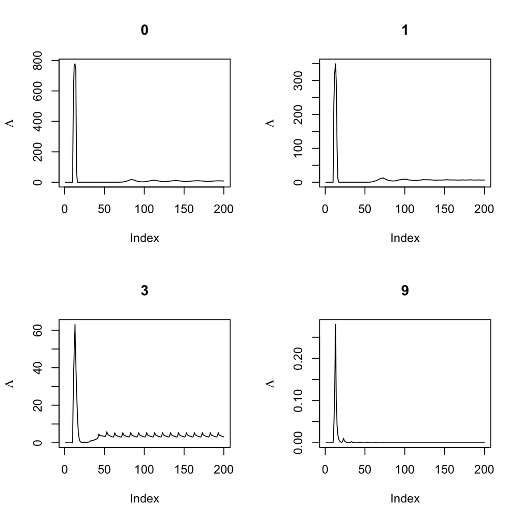

```r
params = makePars()
params$re_treat=10
t1=1
par(mfrow=c(2,2))
params$bti_dose=0
dL_iterate(vars, params, after=t1, mtl = "0") -> out1
params$bti_dose=1
dL_iterate(vars, params, after=t1, mtl = "1") -> out2
params$bti_dose=3
dL_iterate(vars, params, after=t1, mtl = "3") -> out3
params$bti_dose=9
dL_iterate(vars, params, after=t1, mtl = "9") -> out4
```

### P2

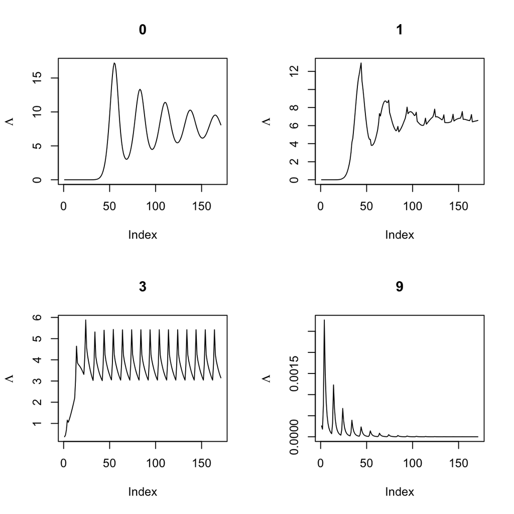

```r
params = makePars()
params$re_treat=10
t1=30
par(mfrow=c(2,2))
params$bti_dose=0
dL_iterate(vars, params, after=t1, mtl = "0") -> out1
params$bti_dose=1
dL_iterate(vars, params, after=t1, mtl = "1") -> out2
params$bti_dose=3
dL_iterate(vars, params, after=t1, mtl = "3") -> out3
params$bti_dose=9
dL_iterate(vars, params, after=t1, mtl = "9") -> out4
```

### P3

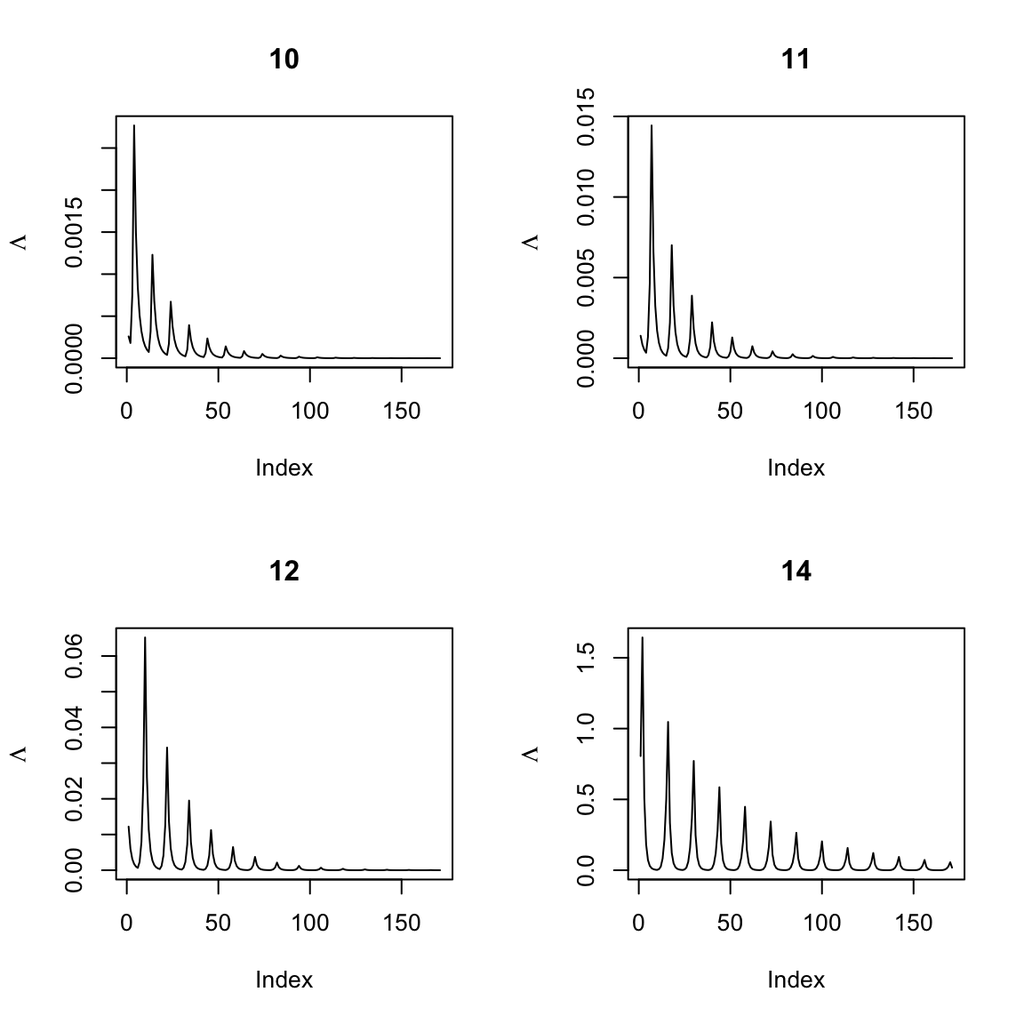

```r
params = makePars()
t1=30
params$bti_dose=9
par(mfrow=c(2,2))
params$re_treat=10
dL_iterate(vars, params, after=t1, mtl = "10") -> sout1
params$re_treat=11
dL_iterate(vars, params, after=t1, mtl = "11") -> sout2
params$re_treat=12
dL_iterate(vars, params, after=t1, mtl = "12") -> sout3
params$re_treat=14
dL_iterate(vars, params, after=t1, mtl = "14") -> sout4
```

### P4

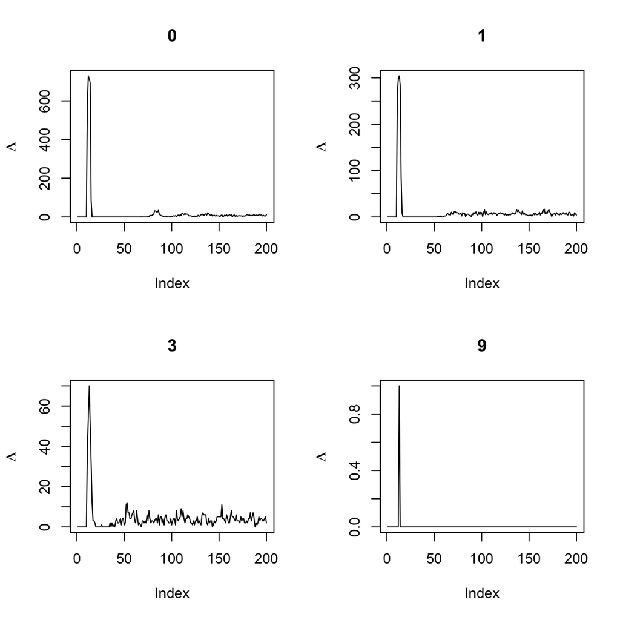

```r
params = makePars()
params$re_treat=10
t1=1
par(mfrow=c(2,2))
params$bti_dose=0
sdL_iterate(vars, params, after=t1, mtl = "0") -> out1
params$bti_dose=1
sdL_iterate(vars, params, after=t1, mtl = "1") -> out2
params$bti_dose=3
sdL_iterate(vars, params, after=t1, mtl = "3") -> out3
params$bti_dose=9
sdL_iterate(vars, params, after=t1, mtl = "9") -> out4
```

### P5

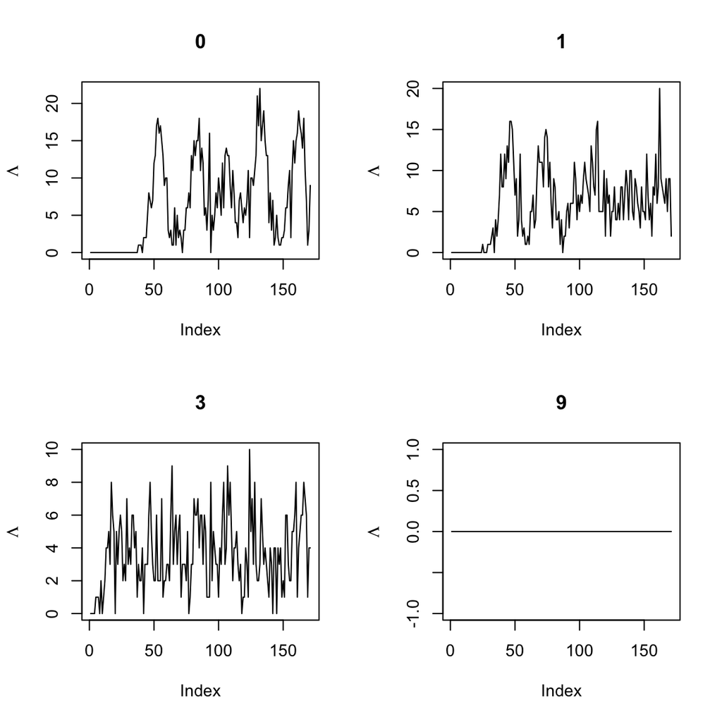

```r
params = makePars()
params$re_treat=10
t1=30
par(mfrow=c(2,2))
params$bti_dose=0
sdL_iterate(vars, params, after=t1, mtl = "0") -> out1
params$bti_dose=1
sdL_iterate(vars, params, after=t1, mtl = "1") -> out2
params$bti_dose=3
sdL_iterate(vars, params, after=t1, mtl = "3") -> out3
params$bti_dose=9
sdL_iterate(vars, params, after=t1, mtl = "9") -> out4
```

### P6

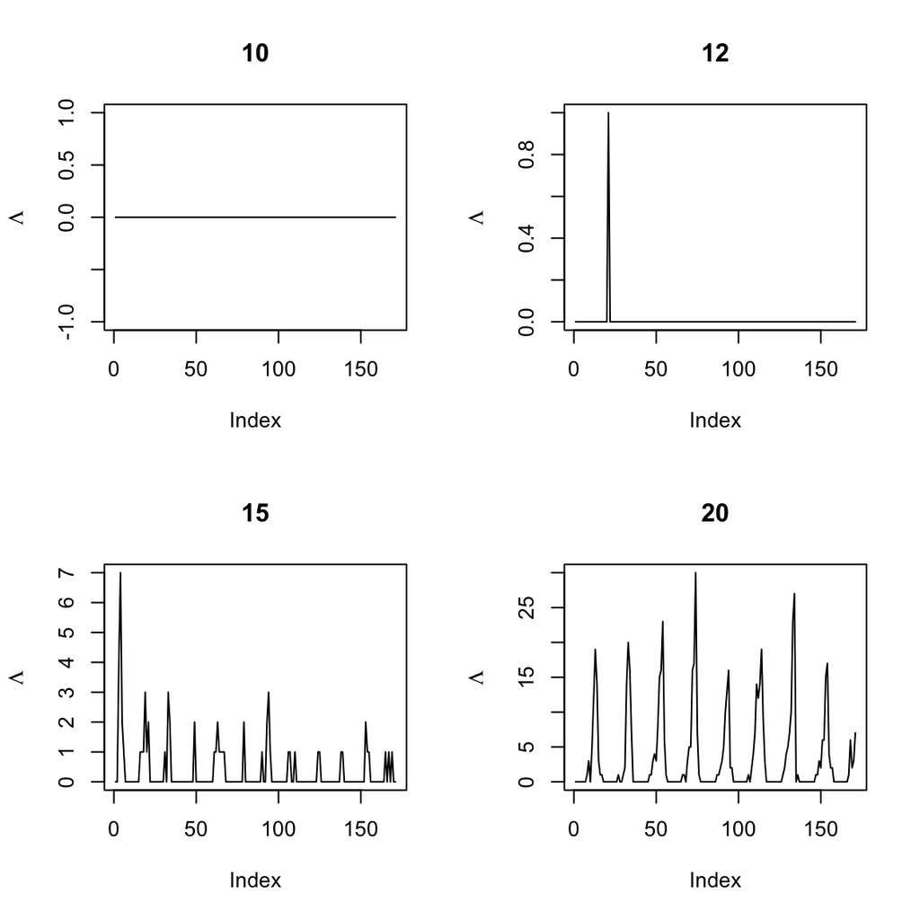

```r
params = makePars()
t1=30
params$bti_dose=9
par(mfrow=c(2,2))
params$re_treat=10
sdL_iterate(vars, params, after=t1, mtl = "10") -> sout1
params$re_treat=12
sdL_iterate(vars, params, after=t1, mtl = "12") -> sout2
params$re_treat=15
sdL_iterate(vars, params, after=t1, mtl = "15") -> sout3
params$re_treat=20
sdL_iterate(vars, params, after=t1, mtl = "20") -> sout4
```